# Predicting Premier League Games

STAT 253: Statistical Machine Learning

Author

Sam, Xander, Tanguy, and Sohail

Published

November 14, 2025

# Research Goals

The objective of this report is to identify key indicators of winning results for Premier League clubs. By way of finding statistical characteristics that best predict winning results, this report will identify key variables and produce a robust model for clubs to employ. While it is true that more favourable statistics often come hand-in-hand with a favourable result, and that conversely, favourable statistics don’t always guarantee results, this report will at a minimum help contextualize results. For instance, if a team wins despite our model predicting a loss based on match data, a coach might conclude that, result aside, the team needs to improve its performance to achieve consistent success rather than relying on statistical outliers.

# Data

Our findings are derived from data from the 21/22 Premier League season. Each row is a game, yielding 380 total observations. Within each row contains logistic information (such as home/away team, date, and referee, etc.) as well as some in-game statistics (corners, red cards, shots on goal, etc.). Our main outcome of interest of course is, “FTR,” or the full time result.

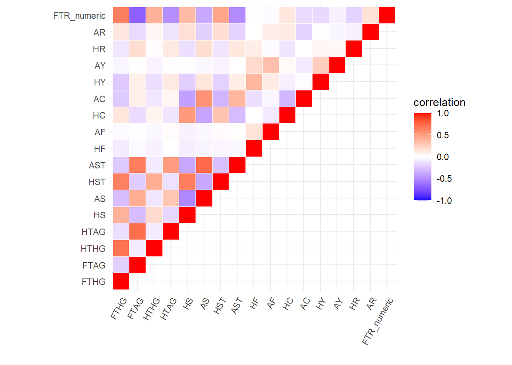

# Model Building

First and foremost, our group pre-screened our variables of interest to maximize insight but also real-world applicability for clubs. Hence, we removed full-time and half-time goal variables, as their relation to the final score is self-evident and takes away from our true findings. Second, we exclude the referee variable because officiating styles vary with factors like foul frequency and home crowd pressure, meaning their inclusion would not yield independent or meaningful insights. We also exclude considerations for individual teams (i.e Manchester City versus Watford). The reasons for this are threefold, first data over only one season wouldn’t generate robust results for either team strength or stadium atmosphere. Second, team performance varies greatly year-to-year, making findings from a previous season, skewed by past performance, obsolete. Finally, relegation muddies our analysis as the Premier League has a distinctly different composition from year to year. We also created last_game_win variables, which simply indicates if the home and away teams have won their previous game. This leaves us with the variables: red cards, yellow cards, shots, shots on target, fouls, corners, and last_game_win.

[figure not shown]

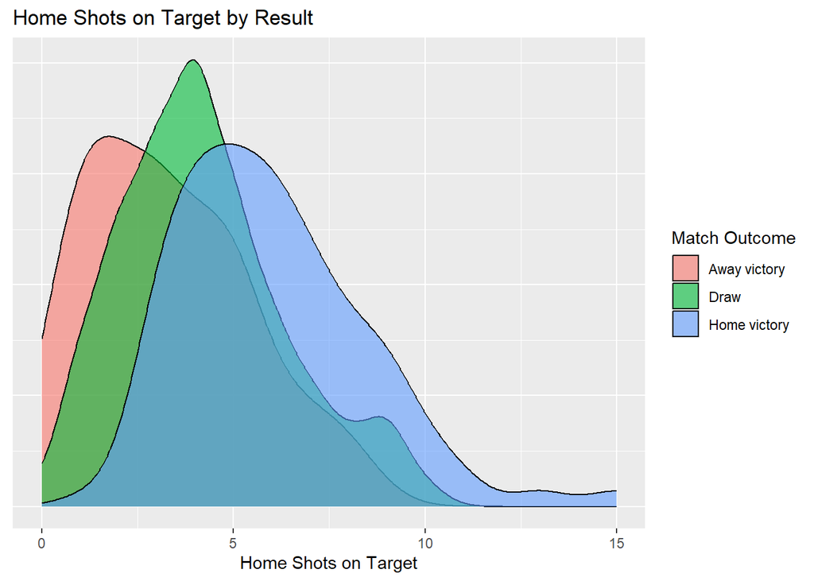

```r
ggplot(data = soccer, aes(x = HST, fill = FTR)) +
  geom_density(alpha = 0.6) +
  scale_fill_discrete(
    labels = c("A" = "Away victory",
               "D" = "Draw",
               "H" = "Home victory")) +
  labs(
    title = "Home Shots on Target by Result",
    x = "Home Shots on Target",
    y = NULL,
    fill = "Match Outcome") +
  theme(axis.text.y  = element_blank(),axis.ticks.y = element_blank())
```

# Implementation

**View Code**

# Model Evaluation

```
parsnip model object

Ranger result

Call:
 ranger::ranger(x = maybe_data_frame(x), y = y, num.trees = ~500,      min.node.size = min_rows(~2, x), probability = ~FALSE, importance = ~"impurity",      num.threads = 1, verbose = FALSE, seed = sample.int(10^5,          1))

Type:                             Classification
Number of trees:                  500
Sample size:                      380
Number of independent variables:  14
Mtry:                             3
Target node size:                 2
Variable importance mode:         impurity
Splitrule:                        gini
OOB prediction error:             40.26 %
```

Our model’s accuracy can be visualized using the below confusion matrix. The matrix shows the relationship between real and predicted values. Accurate predictions are seen in the top left, middle, and bottom right squares, while values in other squares are incorrect predictions. As you can see, our model is much better at predicting wins and losses correctly than it is draws.

```
          Truth
Prediction   A   D   H
         A  88  32  23
         D  14  11  12
         H  27  45 128
```

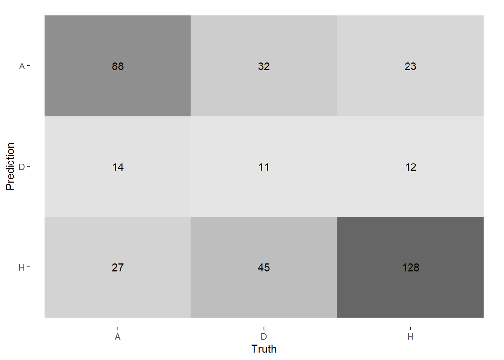

```
               AST                HST                 AS                 HS
         36.621692          33.500953          25.087404          23.247769
                HF                 AC                 HC                 AF
         19.680916          18.964040          18.935329          18.260477
                AY                 HY last_game_win_away last_game_win_home
         14.936339          12.602968           4.951577           4.789630
                HR                 AR
          3.277347           2.114633
```

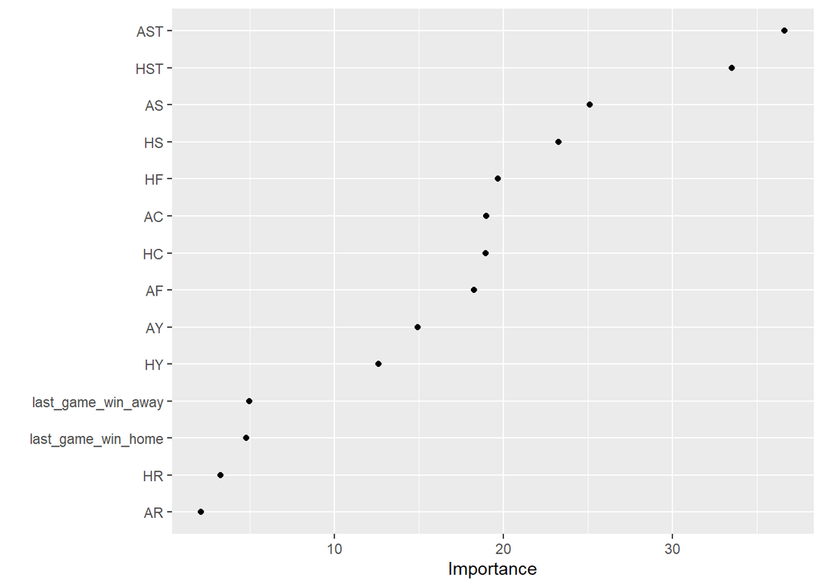

# Contributions

Sohail contributed with reforming data for KNN, fitting and building multiple (20) KNN models with range of K values (1,20) considering the scale of shots of target and shots. He yielded a 60% accuracy with the best model having 13 K Nearest Neighbors. Due to relativelyly lower accuracy we did not end up choosing the KNN model.

Xander contributed primarily to model building and building the correlation matrix. He tried several different models - first 10 trees with different cost-parameter values to find the one with the best accuracy, then creating a tree using bagging, and finally creating a random forest model with 500 trees. We decided on the random forest model because it had the lowest OOB error rate, making it our most accurate model. He did not participate much in the final writeup of the project.

Sam contributed to this project in two ways. The first was model building, as Sam built and tested two models (tree and regression). Neither model was selected for the final report. The second was the creation of the final writeup, as Sam compiled and trimmed the code needed for the final submission, and wrote part of the section on model selection and the full section on model evaluation.

I (Tanguy) helped with the initial data wrangling stage, creating the new “last_game_win” variables and creating a series of visualizations including the density plot that was used in the final report. I also had a large role in the data selection process which helped me write up the Research Goals, Data and half of the Model Building sections. While I ran the tree on my own computer, we did not end up choosing this model. Once the writeup was finished, I proofread the text and identified inconsistencies in our appendices and final forest model.

# Appendix

KNN

```r
# changed it to loss, win and tie for simplicity in classifications

soccer <- soccer %>%
  mutate(FTR_decision = case_when(
    FTR == "A" ~ "Loss",
    FTR == "D" ~ "Tie",
    FTR == "H" ~ "Won",
    TRUE ~ NA_character_ # use NA_character_ for character output
  ))


soccer
```

```r
# Using the top 2 variables (shots on target home and shots on target away) identified by Random Forest to classify
# FTR_Numeric (Full Time Results Numeric). Only using two variables for KNN due to the curse of dimensionality.

result_plot <- soccer %>%
  ggplot(aes(x = HST, y = AST, color = FTR_decision)) +
  geom_point() +
  scale_color_manual(values = c(
    "Won" = "green",
    "Loss" = "red",
    "Tie" = "orange"
  )) +
  theme_minimal()

result_plot
```

```r
# Load packages
library(tidymodels)
library(kknn)

# Resolves package conflicts by preferring tidymodels functions
tidymodels_prefer()
```

```r
# STEP 1: KNN model specification
knn_spec <- nearest_neighbor() %>%
  set_mode("classification") %>%
  set_engine(engine = "kknn") %>%
  set_args(neighbors = tune())

# STEP 2: variable recipe
variable_recipe <- recipe(FTR_decision ~AST + HST, data = soccer) %>%
  step_nzv(all_predictors()) %>%
  step_dummy(all_nominal_predictors()) %>%
  step_normalize(all_numeric_predictors())

# STEP 3: KNN workflow
knn_workflow <- workflow() %>%
  add_recipe(variable_recipe) %>%
  add_model(knn_spec)

# STEP 4: Estimate multiple KNN models using a range of possible K values
set.seed(253)
knn_models <- knn_workflow %>%
  tune_grid(
    grid = grid_regular(neighbors(range = c(1, 20)), levels = 20),
    resamples = vfold_cv(soccer, v = 10),
    metrics = metric_set(accuracy)
  )
```

```r
knn_models %>%
  collect_metrics()
```

```r
knn_models %>%
  autoplot()
```

```r
best_K <- select_best(knn_models, metric = "accuracy")
best_K


# Finding the nearest neighbor value that yields the highest accuracy
```

```r
knn_models %>%
  collect_metrics() %>%
  filter(neighbors == best_K$neighbors)
```

```r
best_K
final_knn_model <- knn_workflow %>%
  finalize_workflow(parameters = best_K) %>%
  fit(data = soccer)
```

```r
new_df<- data.frame(
  AST = 3,
  HST = 7
)

final_knn_model %>%
  predict(new_data = new_df)

#Predicting a new point
```

Tree

```r
soccer_train <- soccer %>%
  select(FTR, HS, AS, HST, AST, HF, AF, HC, AC, HY, AY, HR, AR, last_game_win_home, last_game_win_away)


# STEP 1: tree specification
tree_spec <- decision_tree() %>%
  set_mode("classification") %>%
  set_engine(engine = "rpart") %>%
  set_args(cost_complexity = 0, min_n = 5, tree_depth = 30)


# STEP 2: Build the tree! No tuning (hence no workflows) necessary.
original_tree <- tree_spec %>%
  fit(FTR ~ ., data = soccer_train)

# Plot the tree
original_tree %>%
  extract_fit_engine() %>%
  plot(margin = 0)
original_tree %>%
  extract_fit_engine() %>%
  text(cex = 0.7)
```

Forest of 10 trees:

```r
tree_spec <- decision_tree() %>%
  set_mode("classification") %>%
  set_engine(engine = "rpart") %>%
  set_args(cost_complexity = tune(),
           min_n = 2,
           tree_depth = 30)

variable_recipe_big <- recipe(FTR ~ HS+AS+HST+AST+HF+AF+HC+AC+HY+AY+HR+AR+last_game_win_home+last_game_win_away, data = soccer)

tree_workflow_big <- workflow() %>%
  add_recipe(variable_recipe_big) %>%
  add_model(tree_spec)

set.seed(253)
tree_models_big <- tree_workflow_big %>%
  tune_grid(
    grid = grid_regular(cost_complexity(range = c(-5, 0.1)), levels = 10),
    resamples = vfold_cv(soccer, v = 10),
    metrics = metric_set(accuracy)
  )
```

```r
soccer_tree <- tree_models_big %>%
  select_best(metric = "accuracy")

soccer_tree

show_best(tree_models_big, metric = "accuracy", n = 1)


big_tree <- tree_workflow_big %>%
  finalize_workflow(parameters = soccer_tree) %>%
  fit(data = soccer)

big_tree %>%
  extract_fit_engine() %>%
  rpart.plot(cex = 0.8, type = 0)
```

```r
big_tree %>%
  extract_fit_engine() %>%
  pluck("variable.importance") %>%
  sort(decreasing = TRUE)

library(vip)
big_tree %>%
  vip(geom = "point", num_features = 15)
```

Bagging:

```r
set.seed(3528541) #Xander's number

tree_spec <- decision_tree() %>%
  set_mode("classification") %>%
  set_engine(engine = "rpart") %>%
  set_args(cost_complexity = 0,
           min_n = 2,
           tree_depth = 4)

soccer$FTR <- as.factor(soccer$FTR)


bag_soccer <- sample_n(soccer, size = nrow(soccer), replace = TRUE)

bag_tree <- tree_spec %>%
  fit(FTR ~ HS+AS+HST+AST+HF+AF+HC+AC+HY+AY+HR+AR+last_game_win_home+last_game_win_away,data = soccer)

# Plot your tree
bag_tree %>%
  predict(new_data = soccer) %>%
  cbind(soccer) %>%
  conf_mat(
    truth = FTR,
    estimate = .pred_class
  )

bag_tree %>%
  extract_fit_engine() %>%
  rpart.plot(cex = 0.8, type = 0)
```

Regression

```r
soccer <- soccer[soccer$FTR != "D", ] #exclude draws
```

```r
soccer$FTR <- as.character(soccer$FTR)
soccer$FTR[soccer$FTR == "D"] <- "A" #count draws as losses
soccer$FTR <- as.factor(soccer$FTR)


#Making sure R reads our outcome variable as a binary categorical variable
```

```r
soccer <- soccer %>%
  mutate(FTR = relevel(FTR, ref = "A"))

# Away win is level, this means Home win = 1
```

```r
logistic_spec <- logistic_reg() %>%
  set_mode("classification") %>%
  set_engine("glm")
```

```r
variable_recipe <- recipe(FTR ~ HST + AST + HS + AS + HF + AF + HC + AC + HY + AY + HR + AR + last_game_win_home + last_game_win_away, data = soccer)
```

```r
logistic_workflow <- workflow() %>%
  add_recipe(variable_recipe) %>%
  add_model(logistic_spec)
```

```r
logistic_model <- logistic_workflow %>%
  fit(data = soccer)
```

```r
logistic_model %>%
  tidy()

# Transform coefficients and confidence intervals to the odds scale
# These are odds ratios (OR)
logistic_model %>%
  tidy() %>%
  mutate(
    OR = exp(estimate),
    OR.conf.low = exp(estimate - 1.96*std.error),
    OR.conf.high = exp(estimate + 1.96*std.error)
  )
```

```r
in_sample_classifications <- logistic_model %>%
  augment(new_data = soccer)

# Check it out
head(in_sample_classifications)
```

```r
in_sample_confusion <- in_sample_classifications %>%
  conf_mat(truth = FTR, estimate = .pred_class)
```

```r
# Check it out in table form
in_sample_confusion
```

```r
summary(in_sample_confusion, event_level = "second")
```